# nlp.Rdm

## Natural language processing

### Exploratory data analysis

```r
n1_text <- n_enron %>% filter(f_cluster == 1) %>% select(payload)
n2_text <- n_enron %>% filter(f_cluster == 2) %>% select(payload)
n3_text <- n_enron %>% filter(f_cluster == 3) %>% select(payload)
n1_words <- n1_text %>% unnest_tokens(word, payload)
n2_words <- n2_text %>% unnest_tokens(word, payload)
n3_words <- n3_text %>% unnest_tokens(word, payload)
```

Cluster 1 has the most words, 94013, followed by Cluster 3 with 44366 and Cluster 2 with 38956.

Superficially, there is little difference among the clusters with respect to their ten most frequent words.

```r
n1_words %>% count(word, sort = TRUE)
```

```
## # A tibble: 8,687 x 2
##    word      n
##    <chr> <int>
##  1 the    3164
##  2 to     2707
##  3 i      1902
##  4 you    1744
##  5 ect    1521
##  6 a      1416
##  7 and    1363
##  8 for    1038
##  9 is     1026
## 10 of     1003
## # … with 8,677 more rows
```

```r
n2_words %>% count(word, sort = TRUE)
```

```
## # A tibble: 5,537 x 2
##    word      n
##    <chr> <int>
##  1 the    1457
##  2 to     1285
##  3 i      1245
##  4 you    1011
##  5 and     804
##  6 a       669
##  7 that    553
##  8 of      552
##  9 in      497
## 10 for     470
## # … with 5,527 more rows
```

```r
n3_words %>% count(word, sort = TRUE)
```

```
## # A tibble: 4,680 x 2
##    word       n
##    <chr>  <int>
##  1 the     1638
##  2 to      1372
##  3 i        975
##  4 you      903
##  5 thanks   879
##  6 and      732
##  7 for      680
##  8 this     623
##  9 on       605
## 10 kim      603
## # … with 4,670 more rows
```

Looking at the 100 most frequent words, the pattern is similar. There are some additional first names, the term `enronxgate`. the word `gas` and the number `713`. The first word is also an older email component and `gas` was one of Enron’s busineses. The number is simply the area code for Houston, where Enron’s headquarters were located.

Some filtering is needed. This starts with subtracting a list of the most common words, such as *the* (**stopwords**). There are a variety of stopword lists. Some may be under-inclusive, removing only the most common parts of speech, while others may be over-inclusive, removing words that should be kept. For example, the word `not` often appears on lists of stopwords but is an important term in doing sentiment analysis using phrases – *not good* has a difference valence that *[blank] good*.

The `stop_word` data from the `tidytext` package was hand edited to exempt the following list of works:

```r
exempt_stopwords <- enframe(c("against", "all", "allow", "allows", "always", "awfully", "beforehand", "behind", "below", "better", "big", "can't", "cannot", "cant", "case", "cases", "downwards", "except", "gives", "good", "great", "highest", "hopefully", "immediate", "might", "necessary", "not", "nowhere", "numbers", "otherwise", "point", "serious", "seriously", "state", "states", "unfortunately", "value", "worked", "working", "zero"))
colnames(exempt_stopwords) <- c("line", "word")
stop_words <- anti_join(stop_words, exempt_stopwords)
```

- against
- all
- allow
- allows
- always
- awfully
- beforehand
- behind
- below
- better
- big
- can’t
- cannot
- cant
- case
- cases
- downwards
- except
- gives
- good
- great
- highest
- hopefully
- immediate
- might
- necessary
- not
- nowhere
- numbers
- otherwise
- point
- serious
- seriously
- state
- states
- unfortunately
- value
- worked
- working
- zero

and to add `ect`, `hou` and `enronxgate`.

```r
add_stops <- c("ect", "hou", "enronxgate")
lexicon <- c("user", "user", "user")
new_stops <- cbind(add_stops, lexicon)
colnames(new_stops) <- c("word", "lexicon")
new_stops <- as_tibble(new_stops)
stop_words <- rbind(stop_words, new_stops)
```

Here are the top words in each cluster, after removing the adjusted stopwords and numbers.

```r
n1_text <- n_enron %>% filter(f_cluster == 1) %>% select(payload)
n2_text <- n_enron %>% filter(f_cluster == 2) %>% select(payload)
n3_text <- n_enron %>% filter(f_cluster == 3) %>% select(payload)

n1_words <- n1_text %>%
            unnest_tokens(word, payload) %>%
            anti_join(stop_words) %>%
            filter(word != str_match_all(word,"^\\d+"))
n2_words <- n2_text %>%
            unnest_tokens(word, payload) %>%
            anti_join(stop_words) %>%
            filter(word != str_match_all(word,"^\\d+"))
n3_words <- n3_text %>%
            unnest_tokens(word, payload) %>%
            anti_join(stop_words) %>%
            filter(word != str_match_all(word,"^\\d+"))
n1_words %>% count(word, sort = TRUE) %>% print(n = 25)
```

```
## # A tibble: 7,364 x 2
##    word           n
##    <chr>      <int>
##  1 enron        976
##  2 john         578
##  3 not          485
##  4 cc           390
##  5 subject      390
##  6 errol        309
##  7 arnold       281
##  8 pm           227
##  9 gas          225
## 10 all          209
## 11 corp         198
## 12 deals        188
## 13 time         182
## 14 deal         177
## 15 day          165
## 16 good         165
## 17 call         151
## 18 book         136
## 19 trading      134
## 20 price        126
## 21 eol          123
## 22 dutch        121
## 23 offset       114
## 24 ng           110
## 25 mclaughlin   107
## # … with 7,339 more rows
```

```r
n2_words %>% count(word, sort = TRUE) %>% print(n = 25)
```

```
## # A tibble: 4,732 x 2
##    word          n
##    <chr>     <int>
##  1 not         247
##  2 enron       230
##  3 all         130
##  4 time         93
##  5 call         71
##  6 deal         69
##  7 ken          63
##  8 dg           57
##  9 good         56
## 10 company      49
## 11 day          46
## 12 can't        44
## 13 business     42
## 14 deals        39
## 15 great        38
## 16 people       38
## 17 meeting      35
## 18 working      34
## 19 questions    33
## 20 week         33
## 21 hope         32
## 22 employees    31
## 23 don          30
## 24 gas          30
## 25 talk         30
## # … with 4,707 more rows
```

```r
n3_words %>% count(word, sort = TRUE) %>% print(n = 25)
```

```
## # A tibble: 3,931 x 2
##    word        n
##    <chr>   <int>
##  1 kim       603
##  2 lynn      522
##  3 enron     414
##  4 fyi       204
##  5 meeting   194
##  6 not       179
##  7 ava       126
##  8 tw        115
##  9 all       103
## 10 gas        96
## 11 time       96
## 12 john       95
## 13 steve      91
## 14 call       87
## 15 week       80
## 16 audrey     75
## 17 day        72
## 18 discuss    68
## 19 office     65
## 20 team       62
## 21 good       61
## 22 terry      60
## 23 send       57
## 24 morning    55
## 25 nng        55
## # … with 3,906 more rows
```

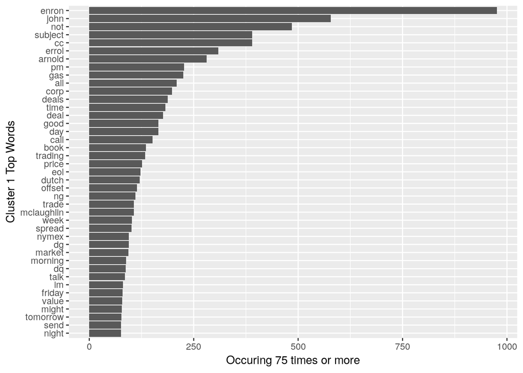

```r
n1_words %>%
  count(word, sort = TRUE)          %>%
  filter(n > 75)                    %>%
  mutate(word = reorder(word, n))   %>%
  ggplot(aes(word,n))               +
  geom_col()                        +
  xlab("Cluster 1 Top Words")       +
  ylab("Occuring 75 times or more") +
  coord_flip()
```

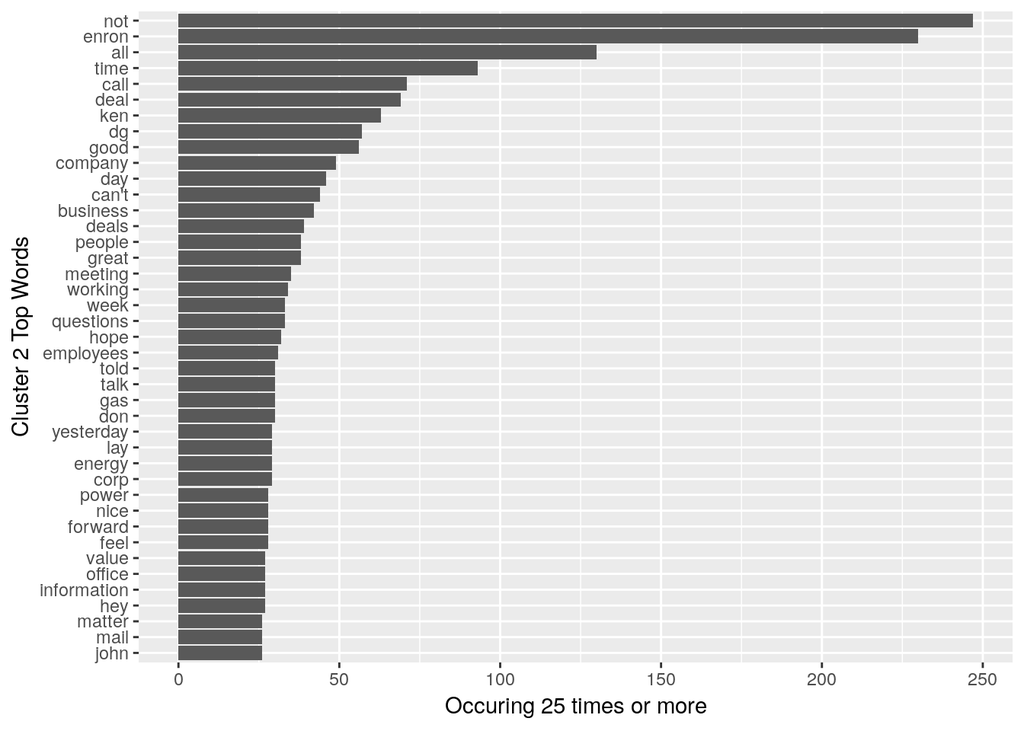

```r
n2_words %>%
  count(word, sort = TRUE)          %>%
  filter(n > 25)                    %>%
  mutate(word = reorder(word, n))   %>%
  ggplot(aes(word,n))               +
  geom_col()                        +
  xlab("Cluster 2 Top Words")       +
  ylab("Occuring 25 times or more") +
  coord_flip()
```

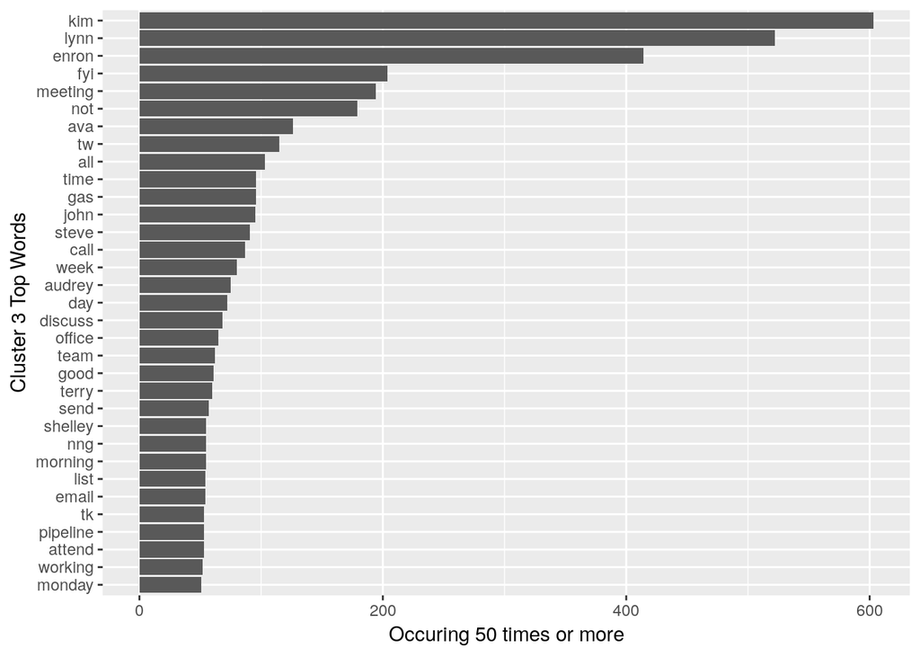

```r
n3_words %>%
  count(word, sort = TRUE)          %>%
  filter(n > 50)                    %>%
  mutate(word = reorder(word, n))   %>%
  ggplot(aes(word,n))               +
  geom_col()                        +
  xlab("Cluster 3 Top Words")       +
  ylab("Occuring 50 times or more") +
  coord_flip()
```

```r
frequency <- bind_rows(mutate(n1_words, cluster = "Cluster 1"),
                       mutate(n2_words, cluster = "Cluster 2"),
                       mutate(n3_words, cluster = "Cluster 3"))  %>%
                       mutate(word = str_extract(word,
                          "[a-z']+"))                           %>%
                       count(cluster, word)                                 %>%
                       group_by(cluster)                                    %>%
                       mutate(proportion = n /sum(n))                   %>%
                       select(-n)                                               %>%
                       spread(cluster, proportion)                      %>%
                       gather(cluster, proportion,
                              `Cluster 2`:`Cluster 3`)

cor.test(data = frequency[frequency$cluster == "Cluster 2",],
          ~ proportion + `Cluster 1`)
```

```
##
##  Pearson's product-moment correlation
##
## data:  proportion and Cluster 1
## t = 53.437, df = 2424, p-value < 2.2e-16
## alternative hypothesis: true correlation is not equal to 0
## 95 percent confidence interval:
##  0.7166135 0.7531884
## sample estimates:
##       cor
## 0.7354362
```

```r
cor.test(data = frequency[frequency$cluster == "Cluster 3",],
         ~ proportion + `Cluster 1`)
```

```
##
##  Pearson's product-moment correlation
##
## data:  proportion and Cluster 1
## t = 31.64, df = 1933, p-value < 2.2e-16
## alternative hypothesis: true correlation is not equal to 0
## 95 percent confidence interval:
##  0.5539780 0.6127321
## sample estimates:
##       cor
## 0.5841197
```

```r
#cor.test(data = frequency[frequency$cluster == "Cluster 3",],
#         ~ proportion + `Cluster 1`)
```

[^1]: Pearon product-moment correlation